# Exercise 05

part 1: making a scatterplot for height

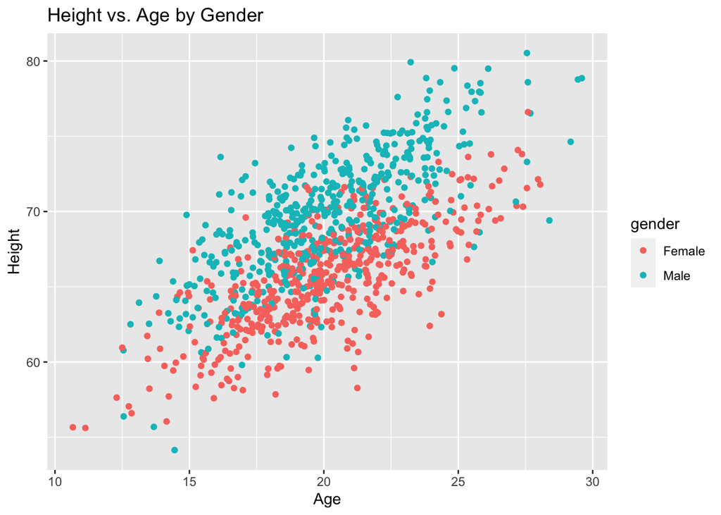

```r
ggplot(z, aes(x = age, y = height, color = gender)) +
  # scatterplot
  geom_point() +
  labs(title = "Height vs. Age by Gender", x = "Age", y = "Height")
```

now I’m doing the exact same thing, but with y = weight instead of height

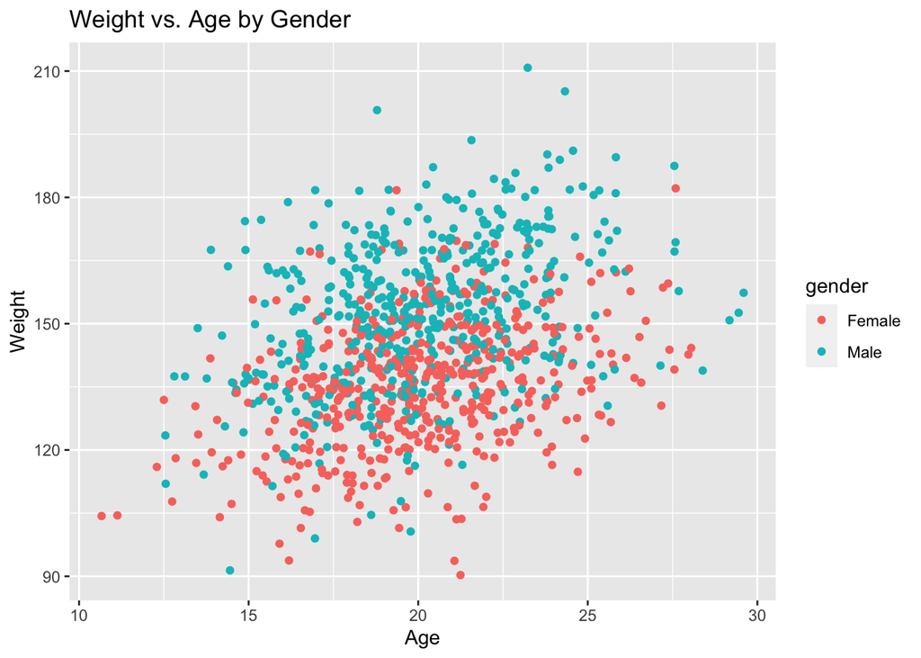

```r
ggplot(z, aes(x = age, y = weight, color = gender)) +
  # scatterplot
  geom_point() +
  labs(title = "Weight vs. Age by Gender", x = "Age", y = "Weight")
```

Step 5:

Using histograms and Q-Q plots, check whether each of the quantitative variables seem to be drawn from a normal distribution.

Quantitative Variables: height, weight, age, zombies_killed, years_of_education

QUESTION: - which seem to be and which do not? - not all are drawn from a normal distribution!! for those that are NOT, can you determine what common distribution they are drawn from?

ANSWER: - based on the histograms and QQ plots shown below, height, weight, and age seem to be normally distributed - HOWEVER, both the number zombies killed and the years of education do not seem to follow a normal distribution - for zombies killed it seems to follow a POISSON distribution - for one, especially in zombies_killed, the histogram shape is more akin to a Poisson distribution, with how left-leaning it is -additionally, Poisson distribution is associated with independently occurring events, suggesting that the number of zombies killed and the years of education, are not highly correlated or dependent on other factors

the histograms can be made with ggplot

for the QQ plots, use {ggpubr} or {car}–> I’m going to be using qqPlot from {car}, as shown in Module 19

HEIGHT histogram/QQ plot

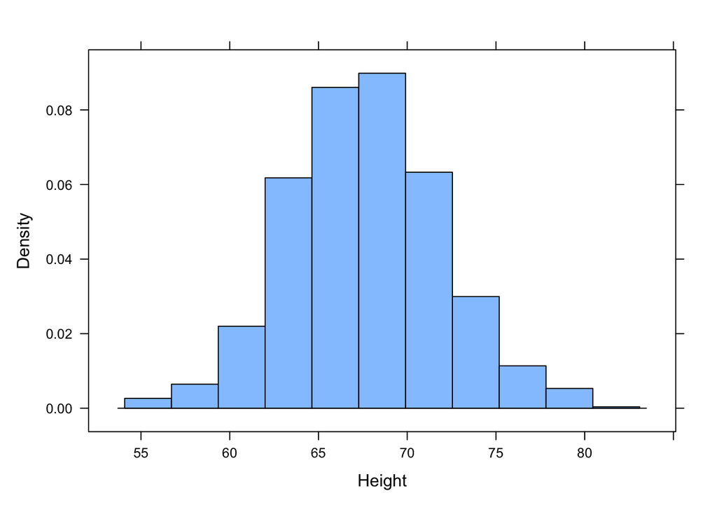

```r
# HISTOGRAM
# starting with the histogram
# using the mosaic package method for quick plotting (as shown in module 19 and 12)
library(mosaic)
# the `histogram()` function from {mosaic} plots neat 'augmented' histograms
histogram(~height, data = z, xlab = "Height")
```

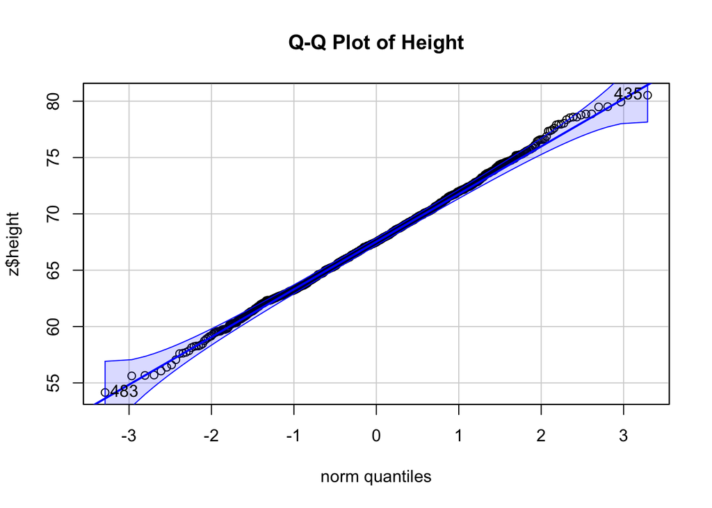

```
## [1] 483 435
```

```r
# QQ PLOT
# I'm using the qqPlot() function from {car}, as used in Module 19
library(car)
# Generate a Q-Q plot for the 'weight' variable
qqPlot(z$height, main = "Q-Q Plot of Height")
```

WEIGHT histogram/QQ plot

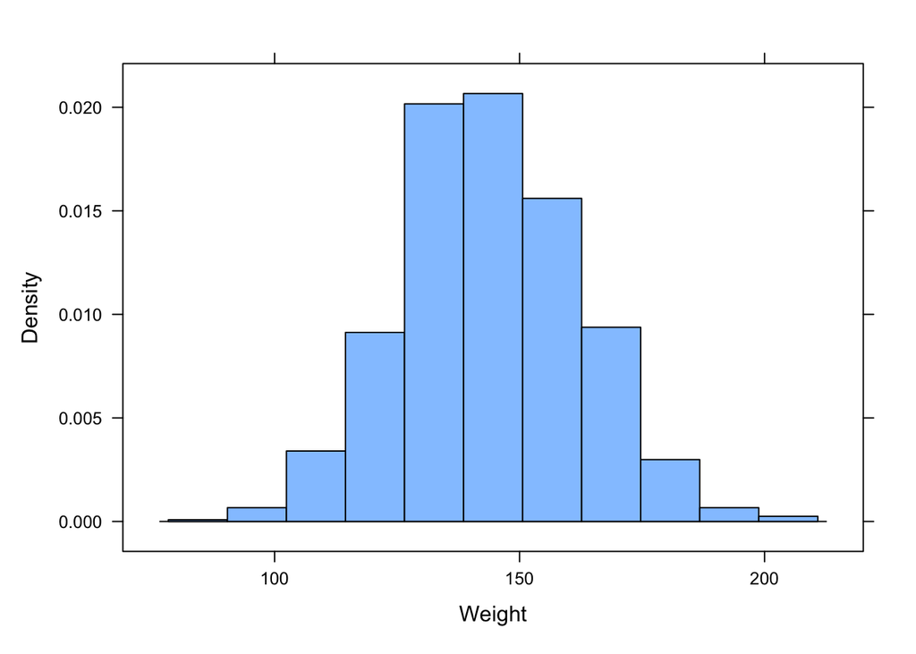

```r
# HISTOGRAM
# starting with the histogram
# using the mosaic package method for quick plotting (as shown in module 19 and 12)
library(mosaic)

# the `histogram()` function from {mosaic} plots neat 'augmented' histograms
histogram(~weight, data = z, xlab = "Weight")
```

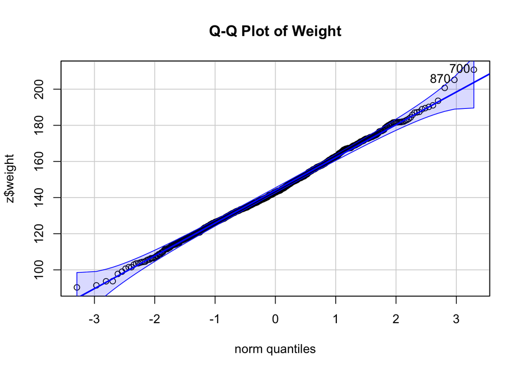

```
## [1] 700 870
```

```r
# QQ PLOT
# I'm using the qqPlot() function from {car}, as used in Module 19
library(car)

# Generate a Q-Q plot for the 'weight' variable
qqPlot(z$weight, main = "Q-Q Plot of Weight")
```

AGE histogram/QQ Plot

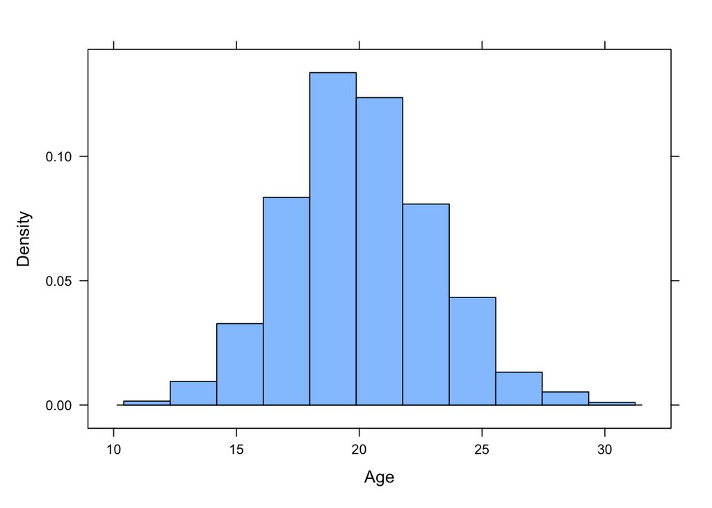

```r
# HISTOGRAM
# starting with the histogram
# using the mosaic package method for quick plotting (as shown in module 19 and 12)
library(mosaic)

# the `histogram()` function from {mosaic} plots neat 'augmented' histograms
histogram(~age, data = z, xlab = "Age")
```

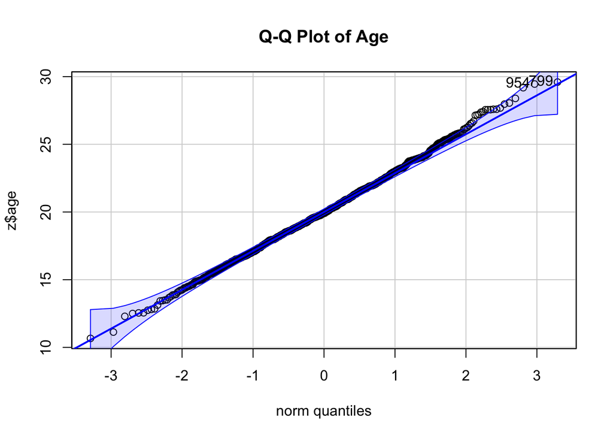

```
## [1] 799 954
```

```r
# QQ PLOT
# I'm using the qqPlot() function from {car}, as used in Module 19
library(car)

# Generate a Q-Q plot for the 'weight' variable
qqPlot(z$age, main = "Q-Q Plot of Age")
```

ZOMBIES_KILLED histogram/ QQ Plot

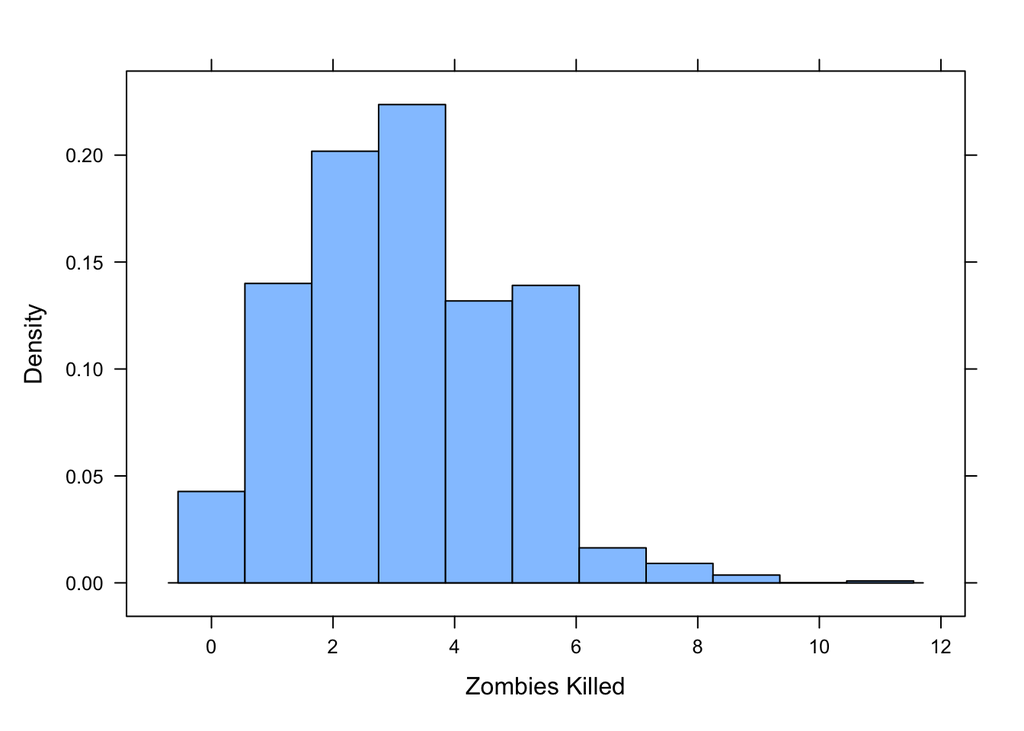

```r
# HISTOGRAM
# starting with the histogram
# using the mosaic package method for quick plotting (as shown in module 19 and 12)
library(mosaic)

# the `histogram()` function from {mosaic} plots neat 'augmented' histograms
histogram(~zombies_killed, data = z, xlab = "Zombies Killed")
```

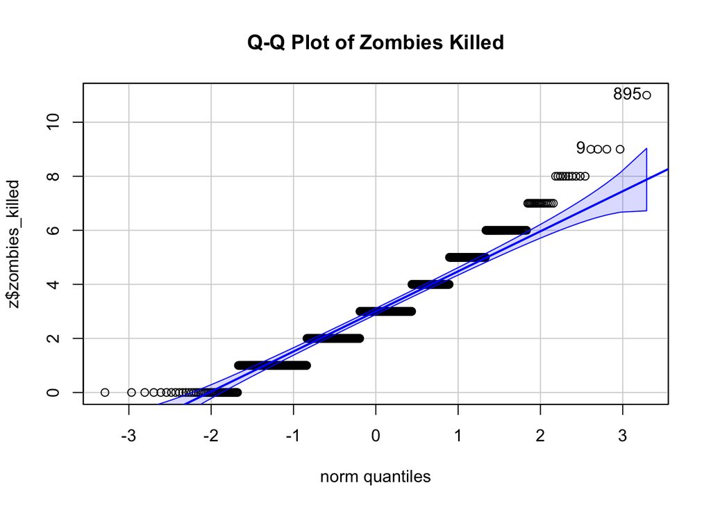

```
## [1] 895   9
```

```r
# QQ PLOT
# I'm using the qqPlot() function from {car}, as used in Module 19
library(car)

# Generate a Q-Q plot for the 'weight' variable

qqPlot(z$zombies_killed, main = "Q-Q Plot of Zombies Killed")
```

YEARS_OF_EDUCATION histogram/QQ plot

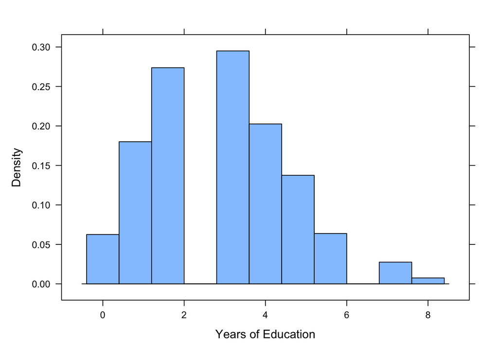

```r
# HISTOGRAM
# starting with the histogram
# using the mosaic package method for quick plotting (as shown in module 19 and 12)
library(mosaic)

# the `histogram()` function from {mosaic} plots neat 'augmented' histograms
histogram(~years_of_education, data = z, xlab = "Years of Education")
```